# python_for_data_science

```python
import numpy as np
import pandas as pd
import matplotlib.pyplot as plt
import seaborn as sns
import scipy.stats as stats
import plotly.express as px
%matplotlib inline
```

```python
df = pd.read_csv('gapminder_clean.csv')
df.describe
```

```
<bound method NDFrame.describe of       Unnamed: 0 Country Name  Year  Agriculture, value added (% of GDP)  \
0              0  Afghanistan  1962                                  NaN
1              1  Afghanistan  1967                                  NaN
2              2  Afghanistan  1972                                  NaN
3              3  Afghanistan  1977                                  NaN
4              4  Afghanistan  1982                                  NaN
...          ...          ...   ...                                  ...
2602        2602     Zimbabwe  1987                            14.407528
2603        2603     Zimbabwe  1992                             7.413793
2604        2604     Zimbabwe  1997                            18.934082
2605        2605     Zimbabwe  2002                            14.029007
2606        2606     Zimbabwe  2007                            21.597907

      CO2 emissions (metric tons per capita)  \
0                                   0.073781
```

[output cut: 142 more lines]

```python
df.head()
```

|  | Unnamed: 0 | Country Name | Year | Agriculture, value added (% of GDP) | CO2 emissions (metric tons per capita) | Domestic credit provided by financial sector (% of GDP) | Electric power consumption (kWh per capita) | Energy use (kg of oil equivalent per capita) | Exports of goods and services (% of GDP) | Fertility rate, total (births per woman) | GDP growth (annual %) | Imports of goods and services (% of GDP) | Industry, value added (% of GDP) | Inflation, GDP deflator (annual %) | Life expectancy at birth, total (years) | Population density (people per sq. km of land area) | Services, etc., value added (% of GDP) | pop | continent | gdpPercap |
| --- | --- | --- | --- | --- | --- | --- | --- | --- | --- | --- | --- | --- | --- | --- | --- | --- | --- | --- | --- | --- |
| 0 | 0 | Afghanistan | 1962 | NaN | 0.073781 | 21.276422 | NaN | NaN | 4.878051 | 7.450 | NaN | 9.349593 | NaN | NaN | 33.219902 | 14.312061 | NaN | 10267083.0 | Asia | 853.100710 |
| 1 | 1 | Afghanistan | 1967 | NaN | 0.123782 | 9.917662 | NaN | NaN | 6.772908 | 7.450 | NaN | 14.209827 | NaN | NaN | 35.389415 | 15.881812 | NaN | 11537966.0 | Asia | 836.197138 |
| 2 | 2 | Afghanistan | 1972 | NaN | 0.130820 | 18.880833 | NaN | NaN | 14.763231 | 7.450 | NaN | 18.105850 | NaN | NaN | 37.610146 | 17.947027 | NaN | 13079460.0 | Asia | 739.981106 |
| 3 | 3 | Afghanistan | 1977 | NaN | 0.183118 | 13.836822 | NaN | NaN | 11.662904 | 7.449 | NaN | 14.823175 | NaN | NaN | 40.110146 | 19.998926 | NaN | 14880372.0 | Asia | 786.113360 |
| 4 | 4 | Afghanistan | 1982 | NaN | 0.165879 | NaN | NaN | NaN | NaN | 7.450 | NaN | NaN | NaN | NaN | 43.230732 | 19.402324 | NaN | 12881816.0 | Asia | 978.011439 |

```python
#Filter the data to include only rows where Year is 1962.
df_1962 = df[df['Year'] == 1962]
```

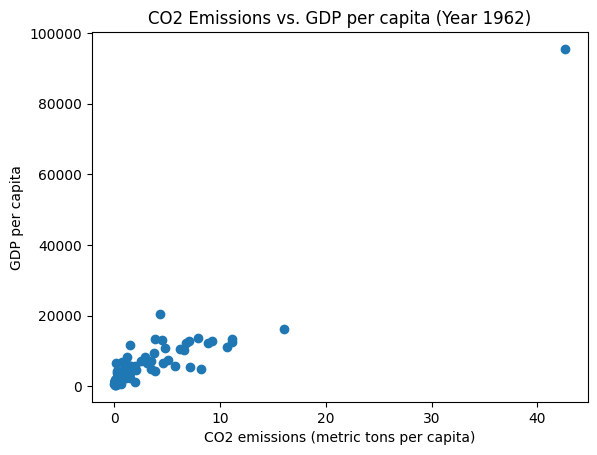

```python
#make a scatter plot comparing 'CO2 emissions (metric tons per capita)' and gdpPercap for the filtered data.
plt.scatter(df_1962['CO2 emissions (metric tons per capita)'], df_1962['gdpPercap'])
plt.title('CO2 Emissions vs. GDP per capita (Year 1962)')
plt.xlabel('CO2 emissions (metric tons per capita)')
plt.ylabel('GDP per capita')
plt.show()
```

```python
#On the filtered data, calculate the correlation of 'CO2 emissions (metric tons per capita)' and gdpPercap.
df_1962.dropna(subset=['CO2 emissions (metric tons per capita)', 'gdpPercap'], inplace=True)
corr, p_value = stats.pearsonr(df_1962['CO2 emissions (metric tons per capita)'], df_1962['gdpPercap'])
print("Correlation:", corr)
print("P-value:", p_value)
```

```
Correlation: 0.9260816725019473
P-value: 1.1286792210036883e-46
```

```python
#On the unfiltered data, answer "In what year is the correlation between 'CO2 emissions (metric tons per capita)' and gdpPercap the strongest?"
corr_by_year = df.groupby('Year').corr(method='pearson')
corr_col = corr_by_year['CO2 emissions (metric tons per capita)'].dropna().abs().idxmax()
strongest_corr_year = corr_by_year.loc[corr_col].name
print(strongest_corr_year)
```

```
(1962, 'CO2 emissions (metric tons per capita)')
```

```python
# Filter the dataset to that year
df_strongest_corr_year = df[df['Year'] == 1962]
df_strongest_corr_year.head(5)
```

|  | Unnamed: 0 | Country Name | Year | Agriculture, value added (% of GDP) | CO2 emissions (metric tons per capita) | Domestic credit provided by financial sector (% of GDP) | Electric power consumption (kWh per capita) | Energy use (kg of oil equivalent per capita) | Exports of goods and services (% of GDP) | Fertility rate, total (births per woman) | GDP growth (annual %) | Imports of goods and services (% of GDP) | Industry, value added (% of GDP) | Inflation, GDP deflator (annual %) | Life expectancy at birth, total (years) | Population density (people per sq. km of land area) | Services, etc., value added (% of GDP) | pop | continent | gdpPercap |
| --- | --- | --- | --- | --- | --- | --- | --- | --- | --- | --- | --- | --- | --- | --- | --- | --- | --- | --- | --- | --- |
| 0 | 0 | Afghanistan | 1962 | NaN | 0.073781 | 21.276422 | NaN | NaN | 4.878051 | 7.450 | NaN | 9.349593 | NaN | NaN | 33.219902 | 14.312061 | NaN | 10267083.0 | Asia | 853.100710 |
| 10 | 10 | Albania | 1962 | NaN | 1.439956 | NaN | NaN | NaN | NaN | 6.282 | NaN | NaN | NaN | NaN | 64.162854 | 62.456898 | NaN | 1728137.0 | Europe | 2312.888958 |
| 20 | 20 | Algeria | 1962 | NaN | 0.484954 | NaN | NaN | NaN | 19.793873 | 7.614 | -19.685042 | 20.818647 | NaN | 2.351279 | 47.045000 | 4.908240 | NaN | 11000948.0 | Africa | 2550.816880 |
| 30 | 30 | American Samoa | 1962 | NaN | NaN | NaN | NaN | NaN | NaN | NaN | NaN | NaN | NaN | NaN | NaN | 105.590000 | NaN | NaN | NaN | NaN |
| 40 | 40 | Andorra | 1962 | NaN | NaN | NaN | NaN | NaN | NaN | NaN | NaN | NaN | NaN | NaN | NaN | 32.714894 | NaN | NaN | NaN | NaN |

```python
df_scatter = df_strongest_corr_year[~df_strongest_corr_year['pop'].isnull()]
df_scatter.head(5)
```

|  | Unnamed: 0 | Country Name | Year | Agriculture, value added (% of GDP) | CO2 emissions (metric tons per capita) | Domestic credit provided by financial sector (% of GDP) | Electric power consumption (kWh per capita) | Energy use (kg of oil equivalent per capita) | Exports of goods and services (% of GDP) | Fertility rate, total (births per woman) | GDP growth (annual %) | Imports of goods and services (% of GDP) | Industry, value added (% of GDP) | Inflation, GDP deflator (annual %) | Life expectancy at birth, total (years) | Population density (people per sq. km of land area) | Services, etc., value added (% of GDP) | pop | continent | gdpPercap |
| --- | --- | --- | --- | --- | --- | --- | --- | --- | --- | --- | --- | --- | --- | --- | --- | --- | --- | --- | --- | --- |
| 0 | 0 | Afghanistan | 1962 | NaN | 0.073781 | 21.276422 | NaN | NaN | 4.878051 | 7.450 | NaN | 9.349593 | NaN | NaN | 33.219902 | 14.312061 | NaN | 10267083.0 | Asia | 853.100710 |
| 10 | 10 | Albania | 1962 | NaN | 1.439956 | NaN | NaN | NaN | NaN | 6.282 | NaN | NaN | NaN | NaN | 64.162854 | 62.456898 | NaN | 1728137.0 | Europe | 2312.888958 |
| 20 | 20 | Algeria | 1962 | NaN | 0.484954 | NaN | NaN | NaN | 19.793873 | 7.614 | -19.685042 | 20.818647 | NaN | 2.351279 | 47.045000 | 4.908240 | NaN | 11000948.0 | Africa | 2550.816880 |
| 50 | 50 | Angola | 1962 | NaN | 0.216025 | NaN | NaN | NaN | NaN | 7.396 | NaN | NaN | NaN | NaN | 33.787585 | 4.384299 | NaN | 4826015.0 | Africa | 4269.276742 |
| 80 | 80 | Argentina | 1962 | NaN | 2.522392 | 17.265977 | NaN | NaN | 4.691843 | 3.089 | -0.852022 | 9.383683 | NaN | 28.871842 | 65.432610 | 7.778624 | NaN | 21283783.0 | Americas | 7133.166023 |

```python
continent = df_scatter['continent'].unique()
continent
```

```
array(['Asia', 'Europe', 'Africa', 'Americas', 'Oceania'], dtype=object)
```

```python
#create an interactive scatter plot comparing 'CO2 emissions (metric tons per capita)' and gdpPercap, where the point size is determined by pop (population) and the color is determined by the continent.
fig = px.scatter(df_scatter, x="CO2 emissions (metric tons per capita)", y="gdpPercap", size="pop", color="continent")
fig.show()
```

Question1:What is the relationship between continent and 'Energy use (kg of oil equivalent per capita)'?

Answer: We used boxplots to visually represent the distribution of energy use across different continents.To determine whether there were statistically significant differences in energy use between the continents, we employed an ANOVA test, ANOVA was chosen because it is suitable for situations where there are multiple groups being compared, in this case we compared energy use across continents with more than two groups (e.g., Africa, Asia, Europe, etc.). The results of the analysis revealed that there are indeed significant differences in energy use among the continents. This suggests that the continent factor has a significant effect on energy use, as the amount of energy used per capita varies significantly across different continents.

```
ANOVA F-value: 51.45915759042634
ANOVA p-value: 8.527003487154367e-39
```

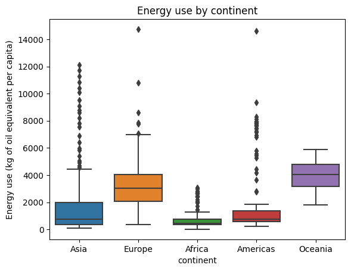

```python
# boxplot
sns.boxplot(data=df,x='continent',y='Energy use (kg of oil equivalent per capita)')
plt.title('Energy use by continent')
plt.ylabel('Energy use (kg of oil equivalent per capita)')
plt.xlabel('continent')

# ANOVA test
df_1 = df[~df['continent'].isnull()]
df_1 = df_1[~df_1['Energy use (kg of oil equivalent per capita)'].isnull()]
df_1.head(5)

fval, pval = stats.f_oneway(df_1[df_1['continent'] == 'Africa']['Energy use (kg of oil equivalent per capita)'],
                           df_1[df_1['continent'] == 'Americas']['Energy use (kg of oil equivalent per capita)'],
                           df_1[df_1['continent'] == 'Asia']['Energy use (kg of oil equivalent per capita)'],
                           df_1[df_1['continent'] == 'Europe']['Energy use (kg of oil equivalent per capita)'],
                           df_1[df_1['continent'] == 'Oceania']['Energy use (kg of oil equivalent per capita)'])


print(f'ANOVA F-value: {fval}')
print(f'ANOVA p-value: {pval}')
```

Question2:Is there a significant difference between Europe and Asia with respect to 'Imports of goods and services (% of GDP)' in the years after 1990? (Stats test needed)

To compare the 'Imports of goods and services (% of GDP)' between Europe and Asia in the years after 1990, we created a line plot to visually represent the trend over time for both continents. Additionally, a t-test was used to determine if there is a statistically significant difference in imports between Europe and Asia. T-test is typically used when comparing two groups on a single variable. The results of the analysis revealed that there are no significant differences in Imports of goods and services (% of GDP)' between Europe and Asia in the years after 1990.

```
T-test statistics:-1.0979607386870058
T-test p-value:0.2735222291887188
```

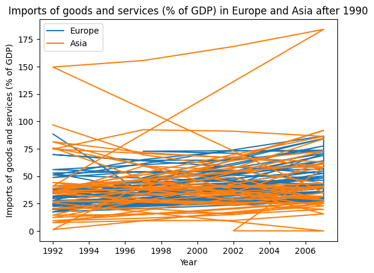

```python
# line plots
df_Europe = df_1[(df_1['continent'] == 'Europe') & (df_1['Year'] > 1990) & ~df_1['Imports of goods and services (% of GDP)'].isnull()]
df_Asia = df_1[(df_1['continent'] == 'Asia') & (df_1['Year'] >1990) & ~df_1['Imports of goods and services (% of GDP)'].isnull()]

plt.plot(df_Europe['Year'],df_Europe['Imports of goods and services (% of GDP)'], label = 'Europe')
plt.plot(df_Asia['Year'],df_Asia['Imports of goods and services (% of GDP)'], label = 'Asia')
plt.title('Imports of goods and services (% of GDP) in Europe and Asia after 1990')
plt.xlabel('Year')
plt.ylabel('Imports of goods and services (% of GDP)')
plt.legend()

# t-test
tstat,pval = stats.ttest_ind(df_Europe['Imports of goods and services (% of GDP)'],
                            df_Asia['Imports of goods and services (% of GDP)'])

print(f'T-test statistics:{tstat}')
print(f'T-test p-value:{pval}')
```

Question3: What is the country (or countries) that has the highest 'Population density (people per sq. km of land area)' across all years? (i.e., which country has the highest average ranking in this category across each time point in the dataset?)

Answer: To find the country (or countries) with the highest 'Population density (people per sq. km of land area)' across all years, we can create a bar chart to visualize the average ranking of population density for each country across all time points in the dataset. Monaco and Macao SAR, China have the highest 'Population density (people per sq. km of land area)' across all years.

```python
# calculate highest 'Population density'
df_rank = df[~df['Population density (people per sq. km of land area)'].isnull()]
df_rank = df_rank[['Year', 'Country Name', 'Population density (people per sq. km of land area)']]
df_rank['rank'] = df_rank.groupby('Year')['Population density (people per sq. km of land area)'].rank()
df_rank_country = df_rank[['Country Name', 'rank']]
df_rank_country = df_rank_country.groupby('Country Name').mean().reset_index()
df_rank_country= df_rank_country.sort_values('rank')
df_rank_country.columns = ['country', 'rank']
df_rank_country.head()
fig = px.bar(data_frame=df_rank_country, x = 'country', y ='rank')
fig.show()

highest_density = df_rank_country['rank'].max()
print(f'highest rank: {highest_density}')

highest_countries = (df_rank_country.loc[df_rank_country['rank']==highest_density])['country'].values.tolist()
print(f'country (or countries) that has the highest density across all years: {highest_countries}')
```

```
highest rank: 255.3
country (or countries) that has the highest density across all years: ['Monaco', 'Macao SAR, China']
```

Question4: What country (or countries) has shown the greatest increase in 'Life expectancy at birth, total (years)' between 1962 and 2007?

Answer: To find the country (or countries) that has shown the greatest increase in 'Life expectancy at birth, total (years)' between 1962 and 2007, we can calculate the difference in life expectancy between 2007 and 1962 for each country, and then sort the countries by this difference in descending order to identify the countries with the greatest increase. Maldives has shown the greatest increase in 'Life expectancy at birth, total (years)' between 1962 and 2007.

```python
#calculate difference in life expectancy between 2007 and 1962 for each country and sort the countries by this difference in descending order
df_lei = df[df['Year'].isin([2007, 1962])]
df_lei = df_lei[['Country Name', 'Year', 'Life expectancy at birth, total (years)']]
df_lei.columns = ['country', 'year', 'le']
df_lei.head()
```

|  | country | year | le |
| --- | --- | --- | --- |
| 0 | Afghanistan | 1962 | 33.219902 |
| 9 | Afghanistan | 2007 | 57.833829 |
| 10 | Albania | 1962 | 64.162854 |
| 19 | Albania | 2007 | 76.470293 |
| 20 | Algeria | 1962 | 47.045000 |

```python
df_lei_pivot = df_lei.pivot(index='country', columns='year', values='le')
df_lei_pivot.reset_index(inplace=True)
df_lei_pivot['lei'] = df_lei_pivot[2007] - df_lei_pivot[1962]
df_lei_pivot = df_lei_pivot[~df_lei_pivot['lei'].isnull()]
df_lei_pivot = df_lei_pivot.sort_values('lei', ascending=False)


highest_lei_increase = df_lei_pivot['lei'].max()
print(f'highest life expectancy increase: {highest_lei_increase}')

highest_lei_countries = (df_lei_pivot.loc[df_lei_pivot['lei']==highest_lei_increase])['country'].values.tolist()

print(f'country (or countries) has shown the greatest increase in Life expectancy at birth between 1962 and 2007: {highest_lei_countries}')
fig_lei = px.bar(df_lei_pivot, x = 'country', y ='lei')
fig_lei.show()
```

```
highest life expectancy increase: 36.916146341499996
country (or countries) has shown the greatest increase in Life expectancy at birth between 1962 and 2007: ['Maldives']
```